# Effects of Promotions on the Sale of GM Cereals

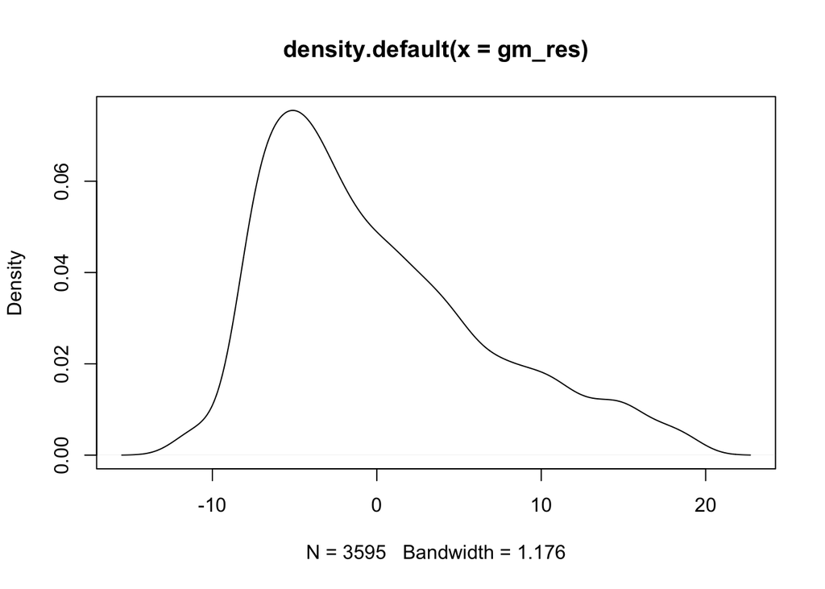

```r
plot(density(gm_res))
```

```r
linearHypothesis(gm_ad_interaction_lm, 'sml_ad_buys1 = med_ad_buys1')
```

```
## Linear hypothesis test
##
## Hypothesis:
## sml_ad_buys1 - med_ad_buys1 = 0
##
## Model 1: restricted model
## Model 2: units ~ sml_ad_buys + med_ad_buys + promo_per_week
##
##   Res.Df    RSS Df Sum of Sq     F Pr(>F)
## 1   3592 162235
## 2   3591 162235  1  0.044072 0.001 0.9751
```

```r
linearHypothesis(gm_ad_interaction_lm, 'promo_per_week1 = 0')
```

```
## Linear hypothesis test
##
## Hypothesis:
## promo_per_week1 = 0
##
## Model 1: restricted model
## Model 2: units ~ sml_ad_buys + med_ad_buys + promo_per_week
##
##   Res.Df    RSS Df Sum of Sq      F    Pr(>F)
## 1   3592 167472
## 2   3591 162235  1    5237.2 115.92 < 2.2e-16 ***
## ---
## Signif. codes:  0 '***' 0.001 '**' 0.01 '*' 0.05 '.' 0.1 ' ' 1
```

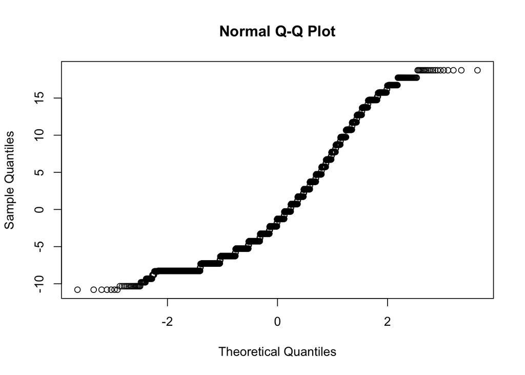

```r
gm_ad_only_lm <- lm(units ~ med_ad_buys + sml_ad_buys, gm_df)
gm_ad_only_res <- resid(gm_ad_only_lm)
qqnorm(gm_ad_only_res)
```

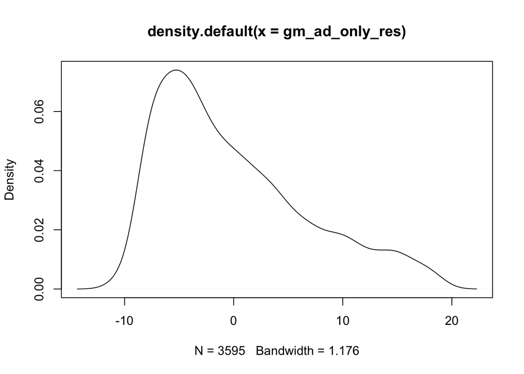

```r
plot(density(gm_ad_only_res))
```

```r
linearHypothesis(gm_ad_only_lm, 'sml_ad_buys1 = 0')
```

```
## Linear hypothesis test
##
## Hypothesis:
## sml_ad_buys1 = 0
##
## Model 1: restricted model
## Model 2: units ~ med_ad_buys + sml_ad_buys
##
##   Res.Df    RSS Df Sum of Sq     F    Pr(>F)
## 1   3593 168323
## 2   3592 167472  1    850.42 18.24 1.998e-05 ***
## ---
## Signif. codes:  0 '***' 0.001 '**' 0.01 '*' 0.05 '.' 0.1 ' ' 1
```

```r
linearHypothesis(gm_ad_only_lm, 'med_ad_buys1 = 0')
```

```
## Linear hypothesis test
##
## Hypothesis:
## med_ad_buys1 = 0
##
## Model 1: restricted model
## Model 2: units ~ med_ad_buys + sml_ad_buys
##
##   Res.Df    RSS Df Sum of Sq      F    Pr(>F)
## 1   3593 168373
## 2   3592 167472  1     901.1 19.327 1.133e-05 ***
## ---
## Signif. codes:  0 '***' 0.001 '**' 0.01 '*' 0.05 '.' 0.1 ' ' 1
```

## 9.1 Observations:

1. All the models have heteroscedasticity indicating some type of correlation within the error.
2. The linear hypothesis testing for the Kellogg interactive model shows that the ad variables indeed have an influence on unit price. The testng also shows that there is a possibility that the influence the ads have are equal. That is not surprising since the coefficients are on .5 apart combined with the heteroscedasticity to induce enough bias.
3. The linear hypothesis test confirms that in the gm interactive model, promo is accurate in its influence on units sold.
4. Further analysis shows that gm small/medium ad weekly combinations have reinforcing effects on units sold.

# 10 Save graphs for use in other documents